# DSC5103 Assignment 5

Decision Trees, Random Forest, and Gradient Boosting Machines

Tong Wang

Oct 2018

## NOTE:

This assignment is **due at 23:59 of Oct 25, Thursday**. You can work on this file directly and fill in your answers/code below. Please submit the output HTML file (name your file like G1Group02.html if you are from Group 02 of Section G1) onto IVLE/Files/Student Submission/Assignment5 folder.

Also, put the Section/Group and member info below.

```r
# Section A1
# Group 13
# Members: RENJIE WEN, XIAO RUI, LI LIPING, WANG XINRUI
```

### Introduction

In this assignment, we will apply tree-based methods (Decision Trees, Random Forest, and GBM) to the heart disease classification problem, and compare them with previous methods we have used.

### Data Preparation

We will use the same **Heart** data, available at http://www-bcf.usc.edu/~gareth/ISL/Heart.csv.

```r
heart <- read.csv(file="http://www-bcf.usc.edu/~gareth/ISL/Heart.csv", row.names=1)
summary(heart)
```

```
##       Age             Sex                ChestPain       RestBP           Chol
##  Min.   :29.00   Min.   :0.0000   asymptomatic:144   Min.   : 94.0   Min.   :126.0
##  1st Qu.:48.00   1st Qu.:0.0000   nonanginal  : 86   1st Qu.:120.0   1st Qu.:211.0
##  Median :56.00   Median :1.0000   nontypical  : 50   Median :130.0   Median :241.0
##  Mean   :54.44   Mean   :0.6799   typical     : 23   Mean   :131.7   Mean   :246.7
##  3rd Qu.:61.00   3rd Qu.:1.0000                      3rd Qu.:140.0   3rd Qu.:275.0
##  Max.   :77.00   Max.   :1.0000                      Max.   :200.0   Max.   :564.0
##
##       Fbs            RestECG           MaxHR           ExAng           Oldpeak         Slope
##  Min.   :0.0000   Min.   :0.0000   Min.   : 71.0   Min.   :0.0000   Min.   :0.00   Min.   :1.000
##  1st Qu.:0.0000   1st Qu.:0.0000   1st Qu.:133.5   1st Qu.:0.0000   1st Qu.:0.00   1st Qu.:1.000
##  Median :0.0000   Median :1.0000   Median :153.0   Median :0.0000   Median :0.80   Median :2.000
##  Mean   :0.1485   Mean   :0.9901   Mean   :149.6   Mean   :0.3267   Mean   :1.04   Mean   :1.601
##  3rd Qu.:0.0000   3rd Qu.:2.0000   3rd Qu.:166.0   3rd Qu.:1.0000   3rd Qu.:1.60   3rd Qu.:2.000
##  Max.   :1.0000   Max.   :2.0000   Max.   :202.0   Max.   :1.0000   Max.   :6.20   Max.   :3.000
##
##        Ca                 Thal      AHD
##  Min.   :0.0000   fixed     : 18   No :164
##  1st Qu.:0.0000   normal    :166   Yes:139
##  Median :0.0000   reversable:117
##  Mean   :0.6722   NA's      :  2
##  3rd Qu.:1.0000
##  Max.   :3.0000
##  NA's   :4
```

The task is to use the features to predict **AHD**, binary outcome related to some heart disease.

Some cleaning is necessary because there are NA’s and also several categorical variables stored as numerical.

```r
# clean the NA's
heart <- na.omit(heart)
# convert to factors
heart$Sex <- as.factor(heart$Sex)
heart$Fbs <- as.factor(heart$Fbs)
heart$RestECG <- as.factor(heart$RestECG)
heart$ExAng <- as.factor(heart$ExAng)
heart$Slope <- as.factor(heart$Slope)
heart$Ca <- as.factor(heart$Ca)
summary(heart)
```

```
##       Age        Sex            ChestPain       RestBP           Chol       Fbs     RestECG
##  Min.   :29.00   0: 96   asymptomatic:142   Min.   : 94.0   Min.   :126.0   0:254   0:147
##  1st Qu.:48.00   1:201   nonanginal  : 83   1st Qu.:120.0   1st Qu.:211.0   1: 43   1:  4
##  Median :56.00           nontypical  : 49   Median :130.0   Median :243.0           2:146
##  Mean   :54.54           typical     : 23   Mean   :131.7   Mean   :247.4
##  3rd Qu.:61.00                              3rd Qu.:140.0   3rd Qu.:276.0
##  Max.   :77.00                              Max.   :200.0   Max.   :564.0
##      MaxHR       ExAng      Oldpeak      Slope   Ca              Thal      AHD
##  Min.   : 71.0   0:200   Min.   :0.000   1:139   0:174   fixed     : 18   No :160
##  1st Qu.:133.0   1: 97   1st Qu.:0.000   2:137   1: 65   normal    :164   Yes:137
##  Median :153.0           Median :0.800   3: 21   2: 38   reversable:115
##  Mean   :149.6           Mean   :1.056           3: 20
##  3rd Qu.:166.0           3rd Qu.:1.600
##  Max.   :202.0           Max.   :6.200
```

Next, we will prepare the training and test dataset for later model comparison.

```r
# split training and test data 50/50
N <- nrow(heart)
set.seed(456)
train.index <- sample(1:N, round(N/2))
test.index <- - train.index
```

Let’s separate the test data for GBM use.

```r
x.test <- heart[test.index, 1:13]
y.test <- heart[test.index, 14]
```

### Questions and Answers

#### 1. [Tree] Fit the optimal tree model using the training data (including growing, cross-validation tree size, and pruning), and use the model to predict the probability of AHD using the test data. (0 Mark)

Answer:

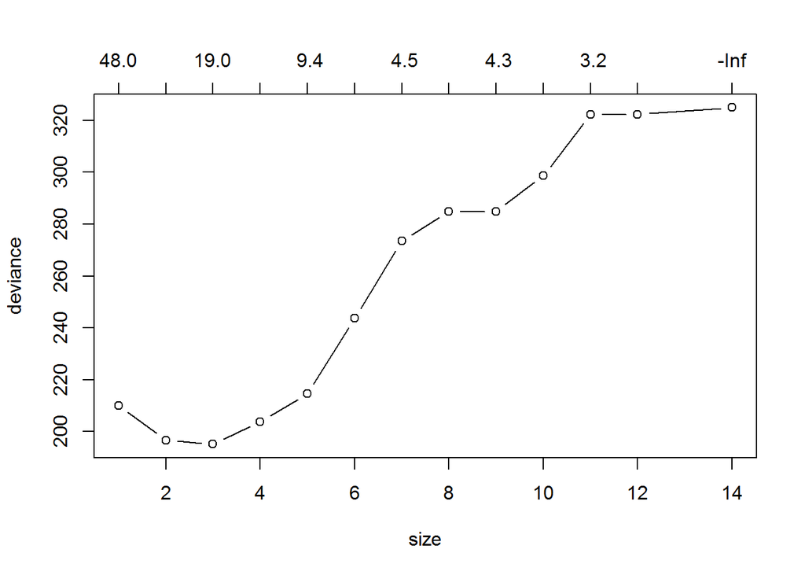

```r
library(tree)
tree <- tree(AHD ~ .,heart, subset = train.index)
#CV
set.seed(456)
tree.cv <- cv.tree(tree)
plot(tree.cv, type="b")
```

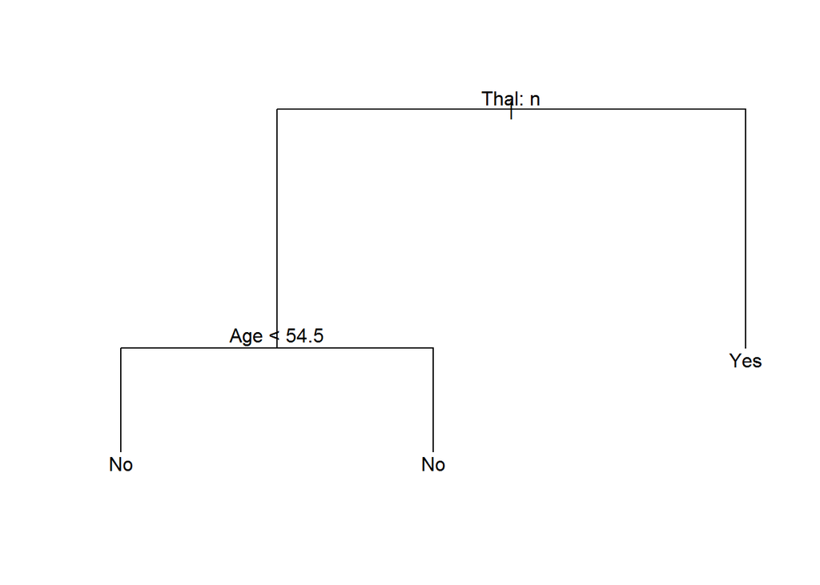

```r
optimal <- which.min(tree.cv$dev)
optimal.k <- tree.cv$k[optimal]
optimal.size <- tree.cv$size[optimal]
#Prune
tree.pruned <- prune.tree(tree,best=optimal.size)
plot(tree.pruned)
text(tree.pruned,pretty=TRUE)
```

```r
# Predict
tree.pred <- predict(tree.pruned, newdata=heart[test.index, ], type="vector")
```

#### 2a. [Random Forest] Fit a Random Forest model with 501 trees on the training data (remember to optimize **mtry**), and predict the probability of AHD on the test data. (1 Mark)

Answer:

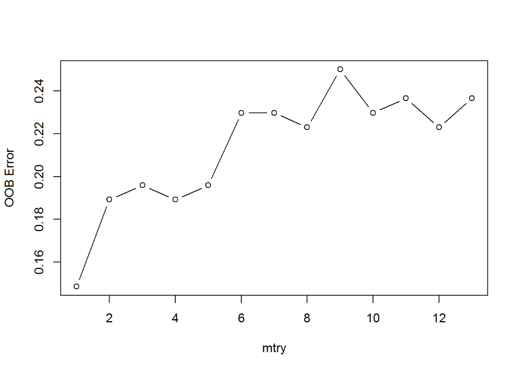

```r
library(randomForest)
set.seed(456)
heart.rf <- randomForest(AHD~ ., data=heart, subset=test.index, ntree=501)

# Tune random forest (mtry) manually
oob.rfs <- rep(1, 13)
for(m in 1:13){
    set.seed(12)
    rf <- randomForest(AHD ~ ., data=heart, subset=train.index, mtry=m,ntree=501 )
    oob.rfs[m] <- rf$err.rate[501,1]
}
plot(1:13, oob.rfs, type="b", xlab="mtry", ylab="OOB Error")
```

```r
optimal <- which.min(oob.rfs) # optimal = 1

heart.rf.tuned <- randomForest(AHD~ ., data=heart, subset=test.index, mtry=optimal, ntree=501)
yhat.rf <- predict(heart.rf.tuned, newdata=heart[test.index,],type="prob")
```

#### 2b. Plot the variable importance and find out how having AHD is related to variables *MaxHR* and *Thal*. Briefly interpret the plots. (1 Mark)

Answer:

```r
# rebuild the model with "importance=TRUE" for more variable importance (%IncMSE)
heart.rf2 <- randomForest(AHD ~ ., data=heart, subset=train.index,ntree=501,mtry=1,importance=TRUE)
heart.rf2
```

```
##
## Call:
##  randomForest(formula = AHD ~ ., data = heart, ntree = 501, mtry = 1,      importance = TRUE, subset = train.index)
##                Type of random forest: classification
##                      Number of trees: 501
## No. of variables tried at each split: 1
##
##         OOB estimate of  error rate: 17.57%
## Confusion matrix:
##     No Yes class.error
## No  66   9   0.1200000
## Yes 17  56   0.2328767
```

```r
# variable importance
importance(heart.rf2)  # by default, we only have IncNodePurity
```

```
##                   No        Yes MeanDecreaseAccuracy MeanDecreaseGini
## Age        3.6737387  4.4581352            5.9347580        4.7678135
## Sex        6.0277090  0.6621083            4.9513192        1.8448377
## ChestPain  6.0727811  8.8963171           10.1440722        4.2779977
## RestBP     1.0377789  5.5031207            4.5684720        4.2884891
## Chol       1.3926592 -3.3797202           -1.1328894        3.9883365
## Fbs        0.8865487 -0.6321959            0.4855665        0.9939873
## RestECG    0.9722249  1.1435914            1.5005085        1.4955556
## MaxHR     10.3024128  9.3462712           12.2277008        6.9976273
## ExAng      7.9308598  6.7636595            8.8323875        2.9551652
## Oldpeak   11.4496912  9.6547204           13.9000631        6.7977211
## Slope      8.4662677  8.8569337           10.7172433        4.1660780
## Ca        11.7838337  8.7284686           12.4280029        4.6882505
## Thal      11.5800040 10.4427422           13.3459459        5.9808851
```

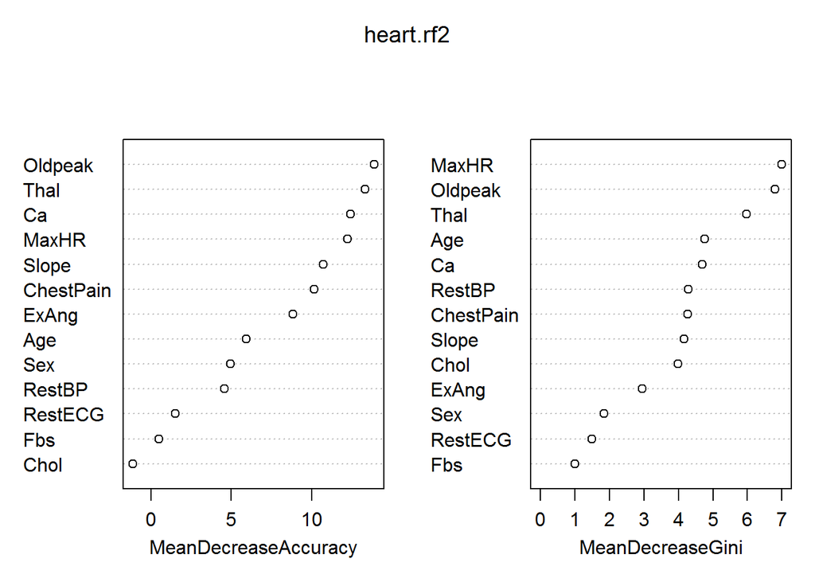

```r
varImpPlot(heart.rf2)
```

Discussion: Since the criteria of variable importance is different in two cases, we have different rankings for different variables. The first graph shows that if a variable is assigned values by random permutation by how much will the MSE increase. $MeanDecreaseAccuracy$ measures how much including a predictor to the model reduces classification error. So if we randomly permute $Thal$ (i.e. an observation which had $thal$ fixed but randomly assign other features normally), the $MeanDecreaseAccuracy$ will decrease by around **13.3%** if we remove $THal$. The higher the value, the higher the variable importance. In this case, $thal$ is more important than $MaxHR$ in predicting $AHD$. In the second graph, variable importantce is measured by $GiniIndex$ which is the difference between RSS before and after the split on that variable. In this case, $MaxHR$ has a low $Gini$ (higher descrease in Gini), which means that it matters more in partitioning the data. $MaxHR$ is more important than $Thal$ in predicting $AHD$.